# FIFA_BEST_PLAYER_PREDICTION

Avoiding warning throughout the cells which are the domain of technical imbalances.

```python
from warnings import filterwarnings
filterwarnings('ignore')
```

### Libraries and Data importing

```python
import pandas as pd
```

```python
import matplotlib.pyplot as plt
plt.rcParams['figure.figsize'] = [15,8]
```

```python
fifa = pd.read_csv('fifa.csv')
fifa.head()
```

|  | ID | Name | Age | Photo | Nationality | Flag | Overall | Potential | Club | Club Logo | ... | Composure | Marking | StandingTackle | SlidingTackle | GKDiving | GKHandling | GKKicking | GKPositioning | GKReflexes | Release Clause |
| --- | --- | --- | --- | --- | --- | --- | --- | --- | --- | --- | --- | --- | --- | --- | --- | --- | --- | --- | --- | --- | --- |
| 0 | 158023 | L. Messi | 31 | https://cdn.sofifa.org/players/4/19/158023.png | Argentina | https://cdn.sofifa.org/flags/52.png | 94 | 94 | FC Barcelona | https://cdn.sofifa.org/teams/2/light/241.png | ... | 96.0 | 33.0 | 28.0 | 26.0 | 6.0 | 11.0 | 15.0 | 14.0 | 8.0 | €226.5M |
| 1 | 20801 | Cristiano Ronaldo | 33 | https://cdn.sofifa.org/players/4/19/20801.png | Portugal | https://cdn.sofifa.org/flags/38.png | 94 | 94 | Juventus | https://cdn.sofifa.org/teams/2/light/45.png | ... | 95.0 | 28.0 | 31.0 | 23.0 | 7.0 | 11.0 | 15.0 | 14.0 | 11.0 | €127.1M |
| 2 | 190871 | Neymar Jr | 26 | https://cdn.sofifa.org/players/4/19/190871.png | Brazil | https://cdn.sofifa.org/flags/54.png | 92 | 93 | Paris Saint-Germain | https://cdn.sofifa.org/teams/2/light/73.png | ... | 94.0 | 27.0 | 24.0 | 33.0 | 9.0 | 9.0 | 15.0 | 15.0 | 11.0 | €228.1M |
| 3 | 193080 | De Gea | 27 | https://cdn.sofifa.org/players/4/19/193080.png | Spain | https://cdn.sofifa.org/flags/45.png | 91 | 93 | Manchester United | https://cdn.sofifa.org/teams/2/light/11.png | ... | 68.0 | 15.0 | 21.0 | 13.0 | 90.0 | 85.0 | 87.0 | 88.0 | 94.0 | €138.6M |
| 4 | 192985 | K. De Bruyne | 27 | https://cdn.sofifa.org/players/4/19/192985.png | Belgium | https://cdn.sofifa.org/flags/7.png | 91 | 92 | Manchester City | https://cdn.sofifa.org/teams/2/light/10.png | ... | 88.0 | 68.0 | 58.0 | 51.0 | 15.0 | 13.0 | 5.0 | 10.0 | 13.0 | €196.4M |

5 rows × 60 columns

```python
fifa.shape
```

```
(18207, 60)
```

We have 60 features in the data. So that we can predict the quality of the players.

# Exploratory Data Analysis

```python
fifa.columns
```

```
Index(['ID', 'Name', 'Age', 'Photo', 'Nationality', 'Flag', 'Overall',
       'Potential', 'Club', 'Club Logo', 'Value', 'Wage', 'Preferred Foot',
       'International Reputation', 'Weak Foot', 'Skill Moves', 'Work Rate',
       'Body Type', 'Position', 'Jersey Number', 'Joined', 'Loaned From',
       'Contract Valid Until', 'Height', 'Weight', 'Crossing', 'Finishing',
       'HeadingAccuracy', 'ShortPassing', 'Volleys', 'Dribbling', 'Curve',
       'FKAccuracy', 'LongPassing', 'BallControl', 'Acceleration',
       'SprintSpeed', 'Agility', 'Reactions', 'Balance', 'ShotPower',
       'Jumping', 'Stamina', 'Strength', 'LongShots', 'Aggression',
       'Interceptions', 'Positioning', 'Vision', 'Penalties', 'Composure',
       'Marking', 'StandingTackle', 'SlidingTackle', 'GKDiving', 'GKHandling',
       'GKKicking', 'GKPositioning', 'GKReflexes', 'Release Clause'],
      dtype='object')
```

```python
(fifa.isna().sum()/fifa.shape[0])*100
```

```
ID                           0.000000
Name                         0.000000
Age                          0.000000
Photo                        0.000000
Nationality                  0.000000
Flag                         0.000000
Overall                      0.000000
Potential                    0.000000
Club                         1.323667
Club Logo                    0.000000
Value                        0.000000
Wage                         0.000000
Preferred Foot               0.263635
International Reputation     0.263635
Weak Foot                    0.263635
Skill Moves                  0.263635
Work Rate                    0.263635
Body Type                    0.263635
Position                     0.329544
Jersey Number                0.329544
Joined                       8.529686
Loaned From                 93.057615
Contract Valid Until         1.587302
Height                       0.263635
Weight                       0.263635
Crossing                     0.263635
Finishing                    0.263635
HeadingAccuracy              0.263635
ShortPassing                 0.263635
Volleys                      0.263635
Dribbling                    0.263635
Curve                        0.263635
FKAccuracy                   0.263635
LongPassing                  0.263635
BallControl                  0.263635
Acceleration                 0.263635
SprintSpeed                  0.263635
Agility                      0.263635
Reactions                    0.263635
Balance                      0.263635
ShotPower                    0.263635
Jumping                      0.263635
Stamina                      0.263635
Strength                     0.263635
LongShots                    0.263635
Aggression                   0.263635
Interceptions                0.263635
Positioning                  0.263635
Vision                       0.263635
Penalties                    0.263635
Composure                    0.263635
Marking                      0.263635
StandingTackle               0.263635
SlidingTackle                0.263635
GKDiving                     0.263635
GKHandling                   0.263635
GKKicking                    0.263635
GKPositioning                0.263635
GKReflexes                   0.263635
Release Clause               8.590103
dtype: float64
```

We obsreve that the feature `Loaned From` has 93% of null values. Which seems to be irrelavent into the data. Since we remove that feature.

```python
fifa_ = fifa.drop('Loaned From', axis = 1)
```

We have estimated the final data. Out of 59, we have 11 features do not contain null values, rest all contain null values. Let's deal with those features.

```python
numeric_data = fifa_.select_dtypes(exclude = object)
print(numeric_data.shape)
```

```
(18207, 42)
```

```python
categorical_data = fifa_.select_dtypes(include = object)
categorical_data.shape
```

```
(18207, 17)
```

Let's observe the datasets:

```python
categorical_data.head()
```

|  | Name | Photo | Nationality | Flag | Club | Club Logo | Value | Wage | Preferred Foot | Work Rate | Body Type | Position | Joined | Contract Valid Until | Height | Weight | Release Clause |
| --- | --- | --- | --- | --- | --- | --- | --- | --- | --- | --- | --- | --- | --- | --- | --- | --- | --- |
| 0 | L. Messi | https://cdn.sofifa.org/players/4/19/158023.png | Argentina | https://cdn.sofifa.org/flags/52.png | FC Barcelona | https://cdn.sofifa.org/teams/2/light/241.png | €110.5M | €565K | Left | Medium/ Medium | Messi | RF | Jul 1, 2004 | 2021 | 5'7 | 159lbs | €226.5M |
| 1 | Cristiano Ronaldo | https://cdn.sofifa.org/players/4/19/20801.png | Portugal | https://cdn.sofifa.org/flags/38.png | Juventus | https://cdn.sofifa.org/teams/2/light/45.png | €77M | €405K | Right | High/ Low | C. Ronaldo | ST | Jul 10, 2018 | 2022 | 6'2 | 183lbs | €127.1M |
| 2 | Neymar Jr | https://cdn.sofifa.org/players/4/19/190871.png | Brazil | https://cdn.sofifa.org/flags/54.png | Paris Saint-Germain | https://cdn.sofifa.org/teams/2/light/73.png | €118.5M | €290K | Right | High/ Medium | Neymar | LW | Aug 3, 2017 | 2022 | 5'9 | 150lbs | €228.1M |
| 3 | De Gea | https://cdn.sofifa.org/players/4/19/193080.png | Spain | https://cdn.sofifa.org/flags/45.png | Manchester United | https://cdn.sofifa.org/teams/2/light/11.png | €72M | €260K | Right | Medium/ Medium | Lean | GK | Jul 1, 2011 | 2020 | 6'4 | 168lbs | €138.6M |
| 4 | K. De Bruyne | https://cdn.sofifa.org/players/4/19/192985.png | Belgium | https://cdn.sofifa.org/flags/7.png | Manchester City | https://cdn.sofifa.org/teams/2/light/10.png | €102M | €355K | Right | High/ High | Normal | RCM | Aug 30, 2015 | 2023 | 5'11 | 154lbs | €196.4M |

```python
categorical_data_ = categorical_data[['Value',
       'Wage', 'Preferred Foot', 'Work Rate', 'Body Type', 'Position',
       'Joined', 'Contract Valid Until', 'Height', 'Weight', 'Release Clause']]
```

```python
categorical_data_.isna().sum()
```

```
Value                      0
Wage                       0
Preferred Foot            48
Work Rate                 48
Body Type                 48
Position                  60
Joined                  1553
Contract Valid Until     289
Height                    48
Weight                    48
Release Clause          1564
dtype: int64
```

```python
categorical_data_.head()
```

|  | Value | Wage | Preferred Foot | Work Rate | Body Type | Position | Joined | Contract Valid Until | Height | Weight | Release Clause |
| --- | --- | --- | --- | --- | --- | --- | --- | --- | --- | --- | --- |
| 0 | €110.5M | €565K | Left | Medium/ Medium | Messi | RF | Jul 1, 2004 | 2021 | 5'7 | 159lbs | €226.5M |
| 1 | €77M | €405K | Right | High/ Low | C. Ronaldo | ST | Jul 10, 2018 | 2022 | 6'2 | 183lbs | €127.1M |
| 2 | €118.5M | €290K | Right | High/ Medium | Neymar | LW | Aug 3, 2017 | 2022 | 5'9 | 150lbs | €228.1M |
| 3 | €72M | €260K | Right | Medium/ Medium | Lean | GK | Jul 1, 2011 | 2020 | 6'4 | 168lbs | €138.6M |
| 4 | €102M | €355K | Right | High/ High | Normal | RCM | Aug 30, 2015 | 2023 | 5'11 | 154lbs | €196.4M |

Value, Wage and Release Clause EDA

```python
# Value:
A = []
for i in categorical_data_['Value'].values:
    A.append(i[-1])

A1 = pd.Series(A)
list(A1.value_counts().index)
```

```
['K', 'M', '0']
```

```python
# Wage:
B = []
for i in categorical_data_['Wage'].values:
    B.append(i[-1])

B1 = pd.Series(B)
list(B1.value_counts().index)
```

```
['K', '0']
```

## For Value

```python
A = list(categorical_data_['Value'].values)

C=[]
for i in range (0,len(A)):
    C.append(list(A[i]))

for i in C:
    i.pop()
    i.pop(0)

D=[]
for i in range(0,len(C)):
    D.append(''.join(C[i]))

E = [pd.to_numeric(i) for i in D]
E1 = [float(i) for i in E]

categorical_data_['Value1'] = E1
```

```python
categorical_data_.shape
```

```
(18207, 12)
```

```python
ind1 = categorical_data_[categorical_data_['Value'].str.contains('M')==True].index
ind2 = categorical_data_[categorical_data_['Value'].str.contains('K')==True].index

categorical_data_['Value11'] = categorical_data_[['Value1']].iloc[ind1,:]
categorical_data_['Value12'] = categorical_data_[['Value1']].iloc[ind2,:]

categorical_data_['Value11'] = categorical_data_['Value11']*1000000
categorical_data_['Value12'] = categorical_data_['Value12']*1000

a = categorical_data_['Value11'].dropna()
b = categorical_data_['Value12'].dropna()

c = pd.concat((a.to_frame(),b.to_frame()),axis=0)
d = c['Value11'].fillna(c['Value12']).to_frame()

e = pd.merge(categorical_data_['Value'], d,left_index=True,right_index=True)
f = e[['Value11']]

df2 = pd.merge(categorical_data_, f,left_index=True,right_index=True)
```

```python
df3 = df2.copy()
```

```python
df3 = df3.drop(['Value','Value1','Value11_x', 'Value12'],axis=1)
```

## For Wage

```python
A = list(df2['Wage'].values)

C=[]
for i in range (0,len(A)):
    C.append(list(A[i]))

for i in C:
    i.pop()
    i.pop(0)

D=[]
for i in range(0,len(C)):
    D.append(''.join(C[i]))

E = [pd.to_numeric(i) for i in D]
E1 = [float(i) for i in E]

df3['Wage1'] = E1
```

```python
df3[['Value11_y','Wage1']].dtypes
```

```
Value11_y    float64
Wage1        float64
dtype: object
```

```python
#ind = df3[df3['Wage'].str.contains('K')==True].index
#ind.shape
```

```python
df3['Wage1'] = df3['Wage1']*1000
```

```python
df3 = df3.drop('Wage', axis=1)
```

We have successfully imputed the values into the 'Value' and 'Wage' attributes.

```python
df3.head(5)
```

|  | Preferred Foot | Work Rate | Body Type | Position | Joined | Contract Valid Until | Height | Weight | Release Clause | Value11_y | Wage1 |
| --- | --- | --- | --- | --- | --- | --- | --- | --- | --- | --- | --- |
| 0 | Left | Medium/ Medium | Messi | RF | Jul 1, 2004 | 2021 | 5'7 | 159lbs | €226.5M | 110500000.0 | 565000.0 |
| 1 | Right | High/ Low | C. Ronaldo | ST | Jul 10, 2018 | 2022 | 6'2 | 183lbs | €127.1M | 77000000.0 | 405000.0 |
| 2 | Right | High/ Medium | Neymar | LW | Aug 3, 2017 | 2022 | 5'9 | 150lbs | €228.1M | 118500000.0 | 290000.0 |
| 3 | Right | Medium/ Medium | Lean | GK | Jul 1, 2011 | 2020 | 6'4 | 168lbs | €138.6M | 72000000.0 | 260000.0 |
| 4 | Right | High/ High | Normal | RCM | Aug 30, 2015 | 2023 | 5'11 | 154lbs | €196.4M | 102000000.0 | 355000.0 |

## For Release Clasuse

```python
df3 = df3.astype({'Release Clause': str})
C = []
for i in df3['Release Clause'].values:
    C.append(i[-1])

C1 = pd.Series(C)
list(C1.value_counts().index)
```

```
['M', 'K', 'n']
```

```python
def RC(x):
    if 'M' in x:
        return x[1]+'0000000'
    elif 'K' in x:
        return x[1]+'00000'
```

```python
df3['Release Clause'] = df3['Release Clause'].apply(RC)
```

```python
df3 = df3.astype({'Release Clause': float})
df3 = df3.astype({'Wage1': float})
df3 = df3.astype({'Value11_y': float})
```

We just made a tentetive change into the Release Cluase with not any specific mathematics. With Value and Wage as well.

```python
df3.head()
```

|  | Preferred Foot | Work Rate | Body Type | Position | Joined | Contract Valid Until | Height | Weight | Release Clause | Value11_y | Wage1 |
| --- | --- | --- | --- | --- | --- | --- | --- | --- | --- | --- | --- |
| 0 | Left | Medium/ Medium | Messi | RF | Jul 1, 2004 | 2021 | 5'7 | 159lbs | 20000000.0 | 110500000.0 | 565000.0 |
| 1 | Right | High/ Low | C. Ronaldo | ST | Jul 10, 2018 | 2022 | 6'2 | 183lbs | 10000000.0 | 77000000.0 | 405000.0 |
| 2 | Right | High/ Medium | Neymar | LW | Aug 3, 2017 | 2022 | 5'9 | 150lbs | 20000000.0 | 118500000.0 | 290000.0 |
| 3 | Right | Medium/ Medium | Lean | GK | Jul 1, 2011 | 2020 | 6'4 | 168lbs | 10000000.0 | 72000000.0 | 260000.0 |
| 4 | Right | High/ High | Normal | RCM | Aug 30, 2015 | 2023 | 5'11 | 154lbs | 10000000.0 | 102000000.0 | 355000.0 |

### Dealing with Height and Weight features

```python
df3[['Height','Weight']].head()
```

|  | Height | Weight |
| --- | --- | --- |
| 0 | 5'7 | 159lbs |
| 1 | 6'2 | 183lbs |
| 2 | 5'9 | 150lbs |
| 3 | 6'4 | 168lbs |
| 4 | 5'11 | 154lbs |

```python
def hei(x):
    return x[0]+'.'+x[2:]

def wei(y):
    return y[:-3]
```

```python
import numpy as np
df3 =df3.astype({'Height': str})
df3 = df3.astype({'Weight': str})

df3['Height'] = df3['Height'].apply(hei)
df3['Weight'] = df3['Weight'].apply(wei)

# ValueError: Unable to parse string "n.n" at position 13236

df3['Height'] = df3['Height'].replace(['n.n'],np.nan) # Remove the unncessery stuff from the data.

df3['Weight']=pd.to_numeric(df3.Weight)  # Essentially converted the value into numeric
df3['Height']=pd.to_numeric(df3.Height)

df3 = df3.astype({'Height': np.float})  # Then converted the value into float
df3 = df3.astype({'Weight': np.float})
```

```python
df3['Weight'] = df3['Weight'] * 0.45359237
```

```python
df3[['Height','Weight','Value11_y','Wage1']].dtypes
```

```
Height       float64
Weight       float64
Value11_y    float64
Wage1        float64
dtype: object
```

We successfully dealt with Hieght and Weight attributes as well as Value and Wage.

## Dealing with date :

```python
df3 = df3.astype({'Joined': str})

D = []
for i in df3.Joined.values:
    D.append(i[-4:])

df3['Joined'] = D

df3['Joined']=pd.DatetimeIndex(df3['Joined']).year
```

```python
df3.head()
```

|  | Preferred Foot | Work Rate | Body Type | Position | Joined | Contract Valid Until | Height | Weight | Release Clause | Value11_y | Wage1 |
| --- | --- | --- | --- | --- | --- | --- | --- | --- | --- | --- | --- |
| 0 | Left | Medium/ Medium | Messi | RF | 2004.0 | 2021 | 5.70 | 72.121187 | 20000000.0 | 110500000.0 | 565000.0 |
| 1 | Right | High/ Low | C. Ronaldo | ST | 2018.0 | 2022 | 6.20 | 83.007404 | 10000000.0 | 77000000.0 | 405000.0 |
| 2 | Right | High/ Medium | Neymar | LW | 2017.0 | 2022 | 5.90 | 68.038855 | 20000000.0 | 118500000.0 | 290000.0 |
| 3 | Right | Medium/ Medium | Lean | GK | 2011.0 | 2020 | 6.40 | 76.203518 | 10000000.0 | 72000000.0 | 260000.0 |
| 4 | Right | High/ High | Normal | RCM | 2015.0 | 2023 | 5.11 | 69.853225 | 10000000.0 | 102000000.0 | 355000.0 |

```python
df3.dtypes
```

```
Preferred Foot           object
Work Rate                object
Body Type                object
Position                 object
Joined                  float64
Contract Valid Until     object
Height                  float64
Weight                  float64
Release Clause          float64
Value11_y               float64
Wage1                   float64
dtype: object
```

Extracting Categorical features

```python
df3.select_dtypes(include = object).head()
```

|  | Preferred Foot | Work Rate | Body Type | Position | Contract Valid Until |
| --- | --- | --- | --- | --- | --- |
| 0 | Left | Medium/ Medium | Messi | RF | 2021 |
| 1 | Right | High/ Low | C. Ronaldo | ST | 2022 |
| 2 | Right | High/ Medium | Neymar | LW | 2022 |
| 3 | Right | Medium/ Medium | Lean | GK | 2020 |
| 4 | Right | High/ High | Normal | RCM | 2023 |

```python
df3['Contract Valid Until'].value_counts()
```

```
2019            4814
2021            4358
2020            4027
2022            1475
2023            1051
Jun 30, 2019     931
2018             886
Dec 31, 2018     144
May 31, 2019      60
Jan 1, 2019       51
2024              23
Jun 30, 2020      14
Jan 31, 2019      13
2025               7
Jan 5, 2019        6
Jan 2, 2019        6
Oct 14, 2019       5
Jan 12, 2019       5
Jan 6, 2019        4
Jan 7, 2019        3
Dec 31, 2019       3
Jan 25, 2019       3
2026               2
Dec 1, 2019        2
May 31, 2020       2
Nov 30, 2018       2
Jan 3, 2019        1
Jan 15, 2019       1
Jan 20, 2019       1
Jan 30, 2019       1
Feb 27, 2020       1
Jan 18, 2019       1
Jun 1, 2019        1
May 4, 2019        1
Jan 4, 2019        1
Jan 11, 2019       1
Name: Contract Valid Until, dtype: int64
```

```python
Z = []
for i in df3['Contract Valid Until'].values:
    Z.append(str(i)[-4:])
```

```python
df3['Contract Valid Until'] = Z
df3 = df3.astype({'Contract Valid Until': float})
```

```python
df3.isna().sum()
```

```
Preferred Foot            48
Work Rate                 48
Body Type                 48
Position                  48
Joined                  1312
Contract Valid Until      48
Height                    48
Weight                    48
Release Clause          1312
Value11_y                  0
Wage1                      0
dtype: int64
```

### Dealing with null values

```python
df3['Preferred Foot'].fillna(df3['Preferred Foot'].mode()[0], inplace = True)
df3['Work Rate'].fillna(df3['Work Rate'].mode()[0], inplace = True)
df3['Body Type'].fillna(df3['Body Type'].mode()[0], inplace = True)
df3['Position'].fillna(df3['Position'].mode()[0], inplace = True)
df3['Joined'].fillna(df3['Joined'].median(), inplace = True)
df3['Contract Valid Until'].fillna(df3['Contract Valid Until'].median(), inplace = True)
df3['Height'].fillna(df3['Height'].median(), inplace = True)
df3['Weight'].fillna(df3['Weight'].median(), inplace = True)
df3['Release Clause'].fillna(df3['Release Clause'].median(), inplace = True)
df3['Value11_y'].fillna(df3['Value11_y'].median(), inplace = True)
df3['Wage1'].fillna(df3['Wage1'].median(), inplace = True)
```

```python
df3.isna().sum()
```

```
Preferred Foot          0
Work Rate               0
Body Type               0
Position                0
Joined                  0
Contract Valid Until    0
Height                  0
Weight                  0
Release Clause          0
Value11_y               0
Wage1                   0
dtype: int64
```

### Encoding on the categorical features

```python
df3 = pd.get_dummies(data = df3 , drop_first= True)
```

```python
df3.shape
```

```
(17955, 51)
```

```python
df3.head()
```

|  | Joined | Contract Valid Until | Height | Weight | Release Clause | Value11_y | Wage1 | Preferred Foot_Right | Work Rate_High/ Low | Work Rate_High/ Medium | ... | Position_RB | Position_RCB | Position_RCM | Position_RDM | Position_RF | Position_RM | Position_RS | Position_RW | Position_RWB | Position_ST |
| --- | --- | --- | --- | --- | --- | --- | --- | --- | --- | --- | --- | --- | --- | --- | --- | --- | --- | --- | --- | --- | --- |
| 0 | 2004.0 | 2021.0 | 5.70 | 72.121187 | 20000000.0 | 110500000.0 | 565000.0 | 0 | 0 | 0 | ... | 0 | 0 | 0 | 0 | 1 | 0 | 0 | 0 | 0 | 0 |
| 1 | 2018.0 | 2022.0 | 6.20 | 83.007404 | 10000000.0 | 77000000.0 | 405000.0 | 1 | 1 | 0 | ... | 0 | 0 | 0 | 0 | 0 | 0 | 0 | 0 | 0 | 1 |
| 2 | 2017.0 | 2022.0 | 5.90 | 68.038855 | 20000000.0 | 118500000.0 | 290000.0 | 1 | 0 | 1 | ... | 0 | 0 | 0 | 0 | 0 | 0 | 0 | 0 | 0 | 0 |
| 3 | 2011.0 | 2020.0 | 6.40 | 76.203518 | 10000000.0 | 72000000.0 | 260000.0 | 1 | 0 | 0 | ... | 0 | 0 | 0 | 0 | 0 | 0 | 0 | 0 | 0 | 0 |
| 4 | 2015.0 | 2023.0 | 5.11 | 69.853225 | 10000000.0 | 102000000.0 | 355000.0 | 1 | 0 | 0 | ... | 0 | 0 | 1 | 0 | 0 | 0 | 0 | 0 | 0 | 0 |

5 rows × 51 columns

### Final Data of Categorical side is prepared.

Categorical Data has been dealt with all possible changes.

```python
numeric_data.head()
```

|  | ID | Age | Overall | Potential | International Reputation | Weak Foot | Skill Moves | Jersey Number | Crossing | Finishing | ... | Penalties | Composure | Marking | StandingTackle | SlidingTackle | GKDiving | GKHandling | GKKicking | GKPositioning | GKReflexes |
| --- | --- | --- | --- | --- | --- | --- | --- | --- | --- | --- | --- | --- | --- | --- | --- | --- | --- | --- | --- | --- | --- |
| 0 | 158023 | 31 | 94 | 94 | 5.0 | 4.0 | 4.0 | 10.0 | 84.0 | 95.0 | ... | 75.0 | 96.0 | 33.0 | 28.0 | 26.0 | 6.0 | 11.0 | 15.0 | 14.0 | 8.0 |
| 1 | 20801 | 33 | 94 | 94 | 5.0 | 4.0 | 5.0 | 7.0 | 84.0 | 94.0 | ... | 85.0 | 95.0 | 28.0 | 31.0 | 23.0 | 7.0 | 11.0 | 15.0 | 14.0 | 11.0 |
| 2 | 190871 | 26 | 92 | 93 | 5.0 | 5.0 | 5.0 | 10.0 | 79.0 | 87.0 | ... | 81.0 | 94.0 | 27.0 | 24.0 | 33.0 | 9.0 | 9.0 | 15.0 | 15.0 | 11.0 |
| 3 | 193080 | 27 | 91 | 93 | 4.0 | 3.0 | 1.0 | 1.0 | 17.0 | 13.0 | ... | 40.0 | 68.0 | 15.0 | 21.0 | 13.0 | 90.0 | 85.0 | 87.0 | 88.0 | 94.0 |
| 4 | 192985 | 27 | 91 | 92 | 4.0 | 5.0 | 4.0 | 7.0 | 93.0 | 82.0 | ... | 79.0 | 88.0 | 68.0 | 58.0 | 51.0 | 15.0 | 13.0 | 5.0 | 10.0 | 13.0 |

5 rows × 42 columns

```python
numeric_data.isna().sum()
```

```
ID                           0
Age                          0
Overall                      0
Potential                    0
International Reputation    48
Weak Foot                   48
Skill Moves                 48
Jersey Number               60
Crossing                    48
Finishing                   48
HeadingAccuracy             48
ShortPassing                48
Volleys                     48
Dribbling                   48
Curve                       48
FKAccuracy                  48
LongPassing                 48
BallControl                 48
Acceleration                48
SprintSpeed                 48
Agility                     48
Reactions                   48
Balance                     48
ShotPower                   48
Jumping                     48
Stamina                     48
Strength                    48
LongShots                   48
Aggression                  48
Interceptions               48
Positioning                 48
Vision                      48
Penalties                   48
Composure                   48
Marking                     48
StandingTackle              48
SlidingTackle               48
GKDiving                    48
GKHandling                  48
GKKicking                   48
GKPositioning               48
GKReflexes                  48
dtype: int64
```

### Dealing with null values by numerical features

```python
from sklearn.impute import KNNImputer
knn_imp = KNNImputer(n_neighbors = 3)
test = knn_imp.fit_transform(numeric_data)
```

```python
numeric_data_ = pd.DataFrame(test, columns = numeric_data.columns)
```

```python
numeric_data_.head()
```

|  | ID | Age | Overall | Potential | International Reputation | Weak Foot | Skill Moves | Jersey Number | Crossing | Finishing | ... | Penalties | Composure | Marking | StandingTackle | SlidingTackle | GKDiving | GKHandling | GKKicking | GKPositioning | GKReflexes |
| --- | --- | --- | --- | --- | --- | --- | --- | --- | --- | --- | --- | --- | --- | --- | --- | --- | --- | --- | --- | --- | --- |
| 0 | 158023.0 | 31.0 | 94.0 | 94.0 | 5.0 | 4.0 | 4.0 | 10.0 | 84.0 | 95.0 | ... | 75.0 | 96.0 | 33.0 | 28.0 | 26.0 | 6.0 | 11.0 | 15.0 | 14.0 | 8.0 |
| 1 | 20801.0 | 33.0 | 94.0 | 94.0 | 5.0 | 4.0 | 5.0 | 7.0 | 84.0 | 94.0 | ... | 85.0 | 95.0 | 28.0 | 31.0 | 23.0 | 7.0 | 11.0 | 15.0 | 14.0 | 11.0 |
| 2 | 190871.0 | 26.0 | 92.0 | 93.0 | 5.0 | 5.0 | 5.0 | 10.0 | 79.0 | 87.0 | ... | 81.0 | 94.0 | 27.0 | 24.0 | 33.0 | 9.0 | 9.0 | 15.0 | 15.0 | 11.0 |
| 3 | 193080.0 | 27.0 | 91.0 | 93.0 | 4.0 | 3.0 | 1.0 | 1.0 | 17.0 | 13.0 | ... | 40.0 | 68.0 | 15.0 | 21.0 | 13.0 | 90.0 | 85.0 | 87.0 | 88.0 | 94.0 |
| 4 | 192985.0 | 27.0 | 91.0 | 92.0 | 4.0 | 5.0 | 4.0 | 7.0 | 93.0 | 82.0 | ... | 79.0 | 88.0 | 68.0 | 58.0 | 51.0 | 15.0 | 13.0 | 5.0 | 10.0 | 13.0 |

5 rows × 42 columns

Assembeling the data

```python
a1 = df3.index
a2 = numeric_data_.index
a3 = []

for i in a2:
    if i not in a1:
        a3.append(i)
```

```python
numeric_data_1 = numeric_data_.drop(a3, axis = 0)
```

```python
FIFA = pd.concat((numeric_data_1, df3), axis = 1)
```

```python
FIFA.head()
```

|  | ID | Age | Overall | Potential | International Reputation | Weak Foot | Skill Moves | Jersey Number | Crossing | Finishing | ... | Position_RB | Position_RCB | Position_RCM | Position_RDM | Position_RF | Position_RM | Position_RS | Position_RW | Position_RWB | Position_ST |
| --- | --- | --- | --- | --- | --- | --- | --- | --- | --- | --- | --- | --- | --- | --- | --- | --- | --- | --- | --- | --- | --- |
| 0 | 158023.0 | 31.0 | 94.0 | 94.0 | 5.0 | 4.0 | 4.0 | 10.0 | 84.0 | 95.0 | ... | 0 | 0 | 0 | 0 | 1 | 0 | 0 | 0 | 0 | 0 |
| 1 | 20801.0 | 33.0 | 94.0 | 94.0 | 5.0 | 4.0 | 5.0 | 7.0 | 84.0 | 94.0 | ... | 0 | 0 | 0 | 0 | 0 | 0 | 0 | 0 | 0 | 1 |
| 2 | 190871.0 | 26.0 | 92.0 | 93.0 | 5.0 | 5.0 | 5.0 | 10.0 | 79.0 | 87.0 | ... | 0 | 0 | 0 | 0 | 0 | 0 | 0 | 0 | 0 | 0 |
| 3 | 193080.0 | 27.0 | 91.0 | 93.0 | 4.0 | 3.0 | 1.0 | 1.0 | 17.0 | 13.0 | ... | 0 | 0 | 0 | 0 | 0 | 0 | 0 | 0 | 0 | 0 |
| 4 | 192985.0 | 27.0 | 91.0 | 92.0 | 4.0 | 5.0 | 4.0 | 7.0 | 93.0 | 82.0 | ... | 0 | 0 | 1 | 0 | 0 | 0 | 0 | 0 | 0 | 0 |

5 rows × 93 columns

```python
FIFA.shape
```

```
(17955, 93)
```

```python
FIFA.isna().sum().sum()
```

```
0
```

## Final Dataset:

```python
ID = FIFA['ID']
FIFA = FIFA.drop('ID', axis = 1)
```

```python
FIFA.columns
```

```
Index(['Age', 'Overall', 'Potential', 'International Reputation', 'Weak Foot',
       'Skill Moves', 'Jersey Number', 'Crossing', 'Finishing',
       'HeadingAccuracy', 'ShortPassing', 'Volleys', 'Dribbling', 'Curve',
       'FKAccuracy', 'LongPassing', 'BallControl', 'Acceleration',
       'SprintSpeed', 'Agility', 'Reactions', 'Balance', 'ShotPower',
       'Jumping', 'Stamina', 'Strength', 'LongShots', 'Aggression',
       'Interceptions', 'Positioning', 'Vision', 'Penalties', 'Composure',
       'Marking', 'StandingTackle', 'SlidingTackle', 'GKDiving', 'GKHandling',
       'GKKicking', 'GKPositioning', 'GKReflexes', 'Joined',
       'Contract Valid Until', 'Height', 'Weight', 'Release Clause',
       'Value11_y', 'Wage1', 'Preferred Foot_Right', 'Work Rate_High/ Low',
       'Work Rate_High/ Medium', 'Work Rate_Low/ High', 'Work Rate_Low/ Low',
       'Work Rate_Low/ Medium', 'Work Rate_Medium/ High',
       'Work Rate_Medium/ Low', 'Work Rate_Medium/ Medium',
       'Body Type_C. Ronaldo', 'Body Type_Courtois', 'Body Type_Lean',
       'Body Type_Messi', 'Body Type_Neymar', 'Body Type_Normal',
       'Body Type_PLAYER_BODY_TYPE_25', 'Body Type_Shaqiri',
       'Body Type_Stocky', 'Position_CB', 'Position_CDM', 'Position_CF',
       'Position_CM', 'Position_GK', 'Position_LAM', 'Position_LB',
       'Position_LCB', 'Position_LCM', 'Position_LDM', 'Position_LF',
       'Position_LM', 'Position_LS', 'Position_LW', 'Position_LWB',
       'Position_RAM', 'Position_RB', 'Position_RCB', 'Position_RCM',
       'Position_RDM', 'Position_RF', 'Position_RM', 'Position_RS',
       'Position_RW', 'Position_RWB', 'Position_ST'],
      dtype='object')
```

```python
FIFA = FIFA.rename({'Value11_y':'Value', 'Wage1':'Wage'}, axis = 1)
```

```python
FIFA.columns
```

```
Index(['Age', 'Overall', 'Potential', 'International Reputation', 'Weak Foot',
       'Skill Moves', 'Jersey Number', 'Crossing', 'Finishing',
       'HeadingAccuracy', 'ShortPassing', 'Volleys', 'Dribbling', 'Curve',
       'FKAccuracy', 'LongPassing', 'BallControl', 'Acceleration',
       'SprintSpeed', 'Agility', 'Reactions', 'Balance', 'ShotPower',
       'Jumping', 'Stamina', 'Strength', 'LongShots', 'Aggression',
       'Interceptions', 'Positioning', 'Vision', 'Penalties', 'Composure',
       'Marking', 'StandingTackle', 'SlidingTackle', 'GKDiving', 'GKHandling',
       'GKKicking', 'GKPositioning', 'GKReflexes', 'Joined',
       'Contract Valid Until', 'Height', 'Weight', 'Release Clause', 'Value',
       'Wage', 'Preferred Foot_Right', 'Work Rate_High/ Low',
       'Work Rate_High/ Medium', 'Work Rate_Low/ High', 'Work Rate_Low/ Low',
       'Work Rate_Low/ Medium', 'Work Rate_Medium/ High',
       'Work Rate_Medium/ Low', 'Work Rate_Medium/ Medium',
       'Body Type_C. Ronaldo', 'Body Type_Courtois', 'Body Type_Lean',
       'Body Type_Messi', 'Body Type_Neymar', 'Body Type_Normal',
       'Body Type_PLAYER_BODY_TYPE_25', 'Body Type_Shaqiri',
       'Body Type_Stocky', 'Position_CB', 'Position_CDM', 'Position_CF',
       'Position_CM', 'Position_GK', 'Position_LAM', 'Position_LB',
       'Position_LCB', 'Position_LCM', 'Position_LDM', 'Position_LF',
       'Position_LM', 'Position_LS', 'Position_LW', 'Position_LWB',
       'Position_RAM', 'Position_RB', 'Position_RCB', 'Position_RCM',
       'Position_RDM', 'Position_RF', 'Position_RM', 'Position_RS',
       'Position_RW', 'Position_RWB', 'Position_ST'],
      dtype='object')
```

We have successfully resolved the issue of NaN values.

Let's drop an feature called **joined**, rather than approaching to that feature, I think **Experience** in year will definitely contribute into the data for model prediction.

```python
from datetime import date

current_date = []
for i in range(FIFA.shape[0]):
    current_date.append(1*date.today().year)

FIFA['Current_Date'] = current_date

FIFA['Experience'] = FIFA['Current_Date'] - FIFA['Joined']

FIFA = FIFA.drop(['Joined','Current_Date'], axis = 1)
```

```python
FIFA.columns
```

```
Index(['Age', 'Overall', 'Potential', 'International Reputation', 'Weak Foot',
       'Skill Moves', 'Jersey Number', 'Crossing', 'Finishing',
       'HeadingAccuracy', 'ShortPassing', 'Volleys', 'Dribbling', 'Curve',
       'FKAccuracy', 'LongPassing', 'BallControl', 'Acceleration',
       'SprintSpeed', 'Agility', 'Reactions', 'Balance', 'ShotPower',
       'Jumping', 'Stamina', 'Strength', 'LongShots', 'Aggression',
       'Interceptions', 'Positioning', 'Vision', 'Penalties', 'Composure',
       'Marking', 'StandingTackle', 'SlidingTackle', 'GKDiving', 'GKHandling',
       'GKKicking', 'GKPositioning', 'GKReflexes', 'Contract Valid Until',
       'Height', 'Weight', 'Release Clause', 'Value', 'Wage',
       'Preferred Foot_Right', 'Work Rate_High/ Low', 'Work Rate_High/ Medium',
       'Work Rate_Low/ High', 'Work Rate_Low/ Low', 'Work Rate_Low/ Medium',
       'Work Rate_Medium/ High', 'Work Rate_Medium/ Low',
       'Work Rate_Medium/ Medium', 'Body Type_C. Ronaldo',
       'Body Type_Courtois', 'Body Type_Lean', 'Body Type_Messi',
       'Body Type_Neymar', 'Body Type_Normal', 'Body Type_PLAYER_BODY_TYPE_25',
       'Body Type_Shaqiri', 'Body Type_Stocky', 'Position_CB', 'Position_CDM',
       'Position_CF', 'Position_CM', 'Position_GK', 'Position_LAM',
       'Position_LB', 'Position_LCB', 'Position_LCM', 'Position_LDM',
       'Position_LF', 'Position_LM', 'Position_LS', 'Position_LW',
       'Position_LWB', 'Position_RAM', 'Position_RB', 'Position_RCB',
       'Position_RCM', 'Position_RDM', 'Position_RF', 'Position_RM',
       'Position_RS', 'Position_RW', 'Position_RWB', 'Position_ST',
       'Experience'],
      dtype='object')
```

**Now our dataset is ready for predictions. Let's make the models for prediction.**

Since, we do not have any feature like predictor, hence we are about to approach to **UNSUPERVISED MACHINE LEARNING** technique.

`MACHINE LEARNING`

# KMeans Clustering

```python
from sklearn.cluster import KMeans
```

Let's pretend some basic features to predict the quality of a player.

```python
X1 = FIFA[['Potential', 'Experience']].values

wcv = []
for i in range(1,5):
    km = KMeans(i)
    km.fit(X1)
    wcv.append(km.inertia_)
```

The range must be begine from 1 itself.

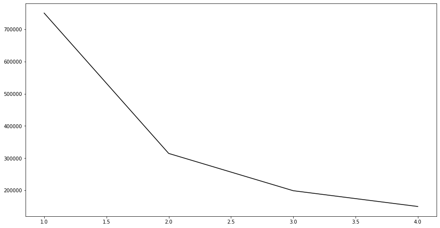

```python
plt.rcParams['figure.figsize'] = [15,8]

plt.plot(range(1,5), wcv, c = 'black')
plt.show()
```

```python
from sklearn.metrics import silhouette_score

silhouette = []

for i in range(2,5):
    km = KMeans(n_clusters = i)
    km.fit(X1)
    silhouette.append(silhouette_score(X1, km.labels_))
```

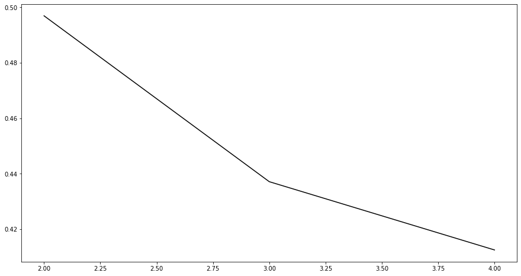

```python
plt.rcParams['figure.figsize'] = [15,8]

plt.plot(range(2,5), silhouette, c = 'black')
plt.show()
```

For these two featres we estimated that, the maximum optimal clusters are 2.

But we are not upto the two features only. We shall have to thnink about other contributing features as well.

Let's initially see the entire data behaviour on `KMeans` clustering.

```python
X2 = FIFA.values

wcv = []
for i in range(1,5):
    km = KMeans(i)
    km.fit(X2)
    wcv.append(km.inertia_)
```

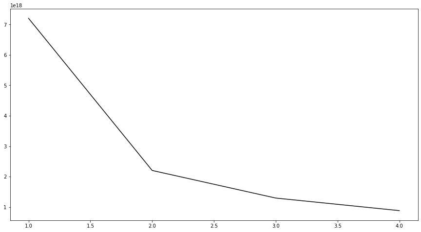

```python
plt.rcParams['figure.figsize'] = [15,8]

plt.plot(range(1,5), wcv, c = 'black')
plt.show()
```

```python
from sklearn.metrics import silhouette_score

silhouette = []

for i in range(2,5):
    km = KMeans(n_clusters = i)
    km.fit(X2)
    silhouette.append(silhouette_score(X2, km.labels_))
```

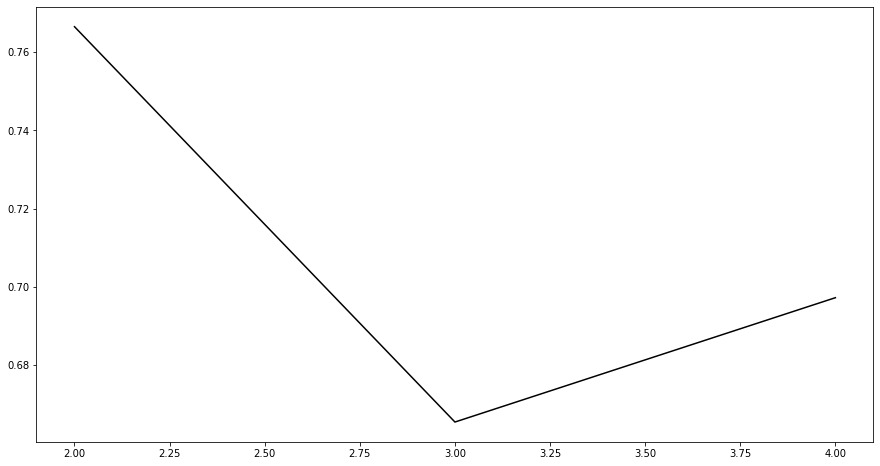

```python
plt.rcParams['figure.figsize'] = [15,8]

plt.plot(range(2,5), silhouette, c = 'black')
plt.show()
```

**AMAZING!** We eventually get the same information into this scenario as well, our cliam is absolutely right, we can see that the complete data makes two clusters.

Our duty is to justify the player. And we say either the player is `Good` or `Not good`. Let's make the prediction with KMeans algorithm.

```python
km = KMeans(n_clusters = 2)
km_pred = km.fit_predict(X2)
km_pred_2 = km.fit_predict(X1)
```

```python
fake_data = FIFA.copy()
fake_data['class'] = km_pred
fake_data['class2'] = km_pred_2
```

```python
print(fake_data['class'].value_counts())
print()
print(fake_data['class2'].value_counts())
```

```
0    15820
1     2135
Name: class, dtype: int64

0    9591
1    8364
Name: class2, dtype: int64
```

Since we observed that, when we used the two important features to predict the quality of the player. We got an amazing perediction. But if we see for the entire data, thing changed and we see a giant difference. The thing is, we ensure that, if the features are more, the goodness or the quality is the same rate of change of the target variable.

Since we know that, we have a huge data. Let's work on the data, where we would deal with only those features which basically numeric and undummied.

```python
X3 = FIFA[['Age', 'Overall', 'Potential','Value', 'Wage',   'International Reputation',
          'Height', 'Weight', 'Crossing', 'Finishing', 'Experience','Crossing', 'Finishing',
       'HeadingAccuracy', 'ShortPassing', 'Volleys', 'Dribbling', 'Curve',
       'FKAccuracy', 'LongPassing', 'BallControl', 'Acceleration',
       'SprintSpeed', 'Agility',  'Balance', 'ShotPower',
       'Jumping', 'Stamina', 'Strength', 'LongShots', 'Aggression',
       'Interceptions', 'Positioning', 'Vision', 'Penalties']]
```

```python
X3.dtypes
```

```
Age                         float64
Overall                     float64
Potential                   float64
Value                       float64
Wage                        float64
International Reputation    float64
Height                      float64
Weight                      float64
Crossing                    float64
Finishing                   float64
Experience                  float64
Crossing                    float64
Finishing                   float64
HeadingAccuracy             float64
ShortPassing                float64
Volleys                     float64
Dribbling                   float64
Curve                       float64
FKAccuracy                  float64
LongPassing                 float64
BallControl                 float64
Acceleration                float64
SprintSpeed                 float64
Agility                     float64
Balance                     float64
ShotPower                   float64
Jumping                     float64
Stamina                     float64
Strength                    float64
LongShots                   float64
Aggression                  float64
Interceptions               float64
Positioning                 float64
Vision                      float64
Penalties                   float64
dtype: object
```

All these features are done with numerical scores. Let's make the prediction using this data.

```python
wcv = []
for i in range(1,5):
    km = KMeans(i)
    km.fit(X3)
    wcv.append(km.inertia_)
```

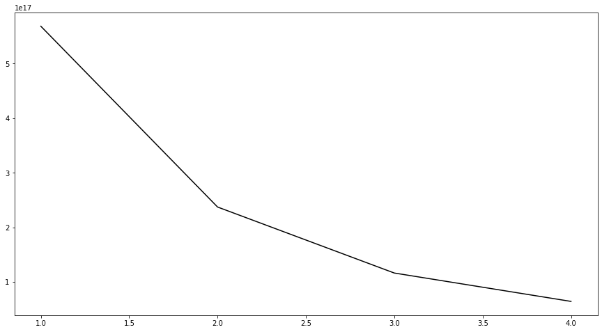

```python
plt.rcParams['figure.figsize'] = [15,8]

plt.plot(range(1,5), wcv, c = 'black')
plt.show()
```

```python
from sklearn.metrics import silhouette_score

silhouette = []

for i in range(2,5):
    km = KMeans(n_clusters = i)
    km.fit(X3)
    silhouette.append(silhouette_score(X3, km.labels_))
```

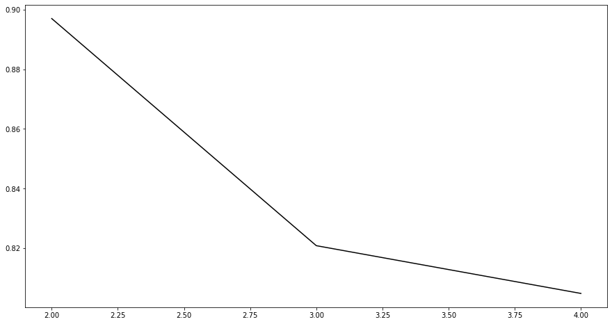

```python
plt.rcParams['figure.figsize'] = [15,8]

plt.plot(range(2,5), silhouette, c = 'black')
plt.show()
```

```python
km = KMeans(n_clusters = 2)
km_pred_3 = km.fit_predict(X3)
```

```python
fake_data['class3'] = km_pred_3
```

```python
print(fake_data['class'].value_counts())
print()
print(fake_data['class2'].value_counts())
print()
print(fake_data['class3'].value_counts())
```

```
0    15820
1     2135
Name: class, dtype: int64

0    9591
1    8364
Name: class2, dtype: int64

0    17544
1      411
Name: class3, dtype: int64
```

What we have chosen the features are not that much good for the contribution. Hence we see, a lot of misbalancing into the data. Hence we are about to go for checking each and every feature. Whichever be the feature gives the good prediction, we are goign to standby that.

Therefore to deal with such case we work with the technique called `PCA: Principal Component Analysis`.

# Clustering with Principal Component Analysis

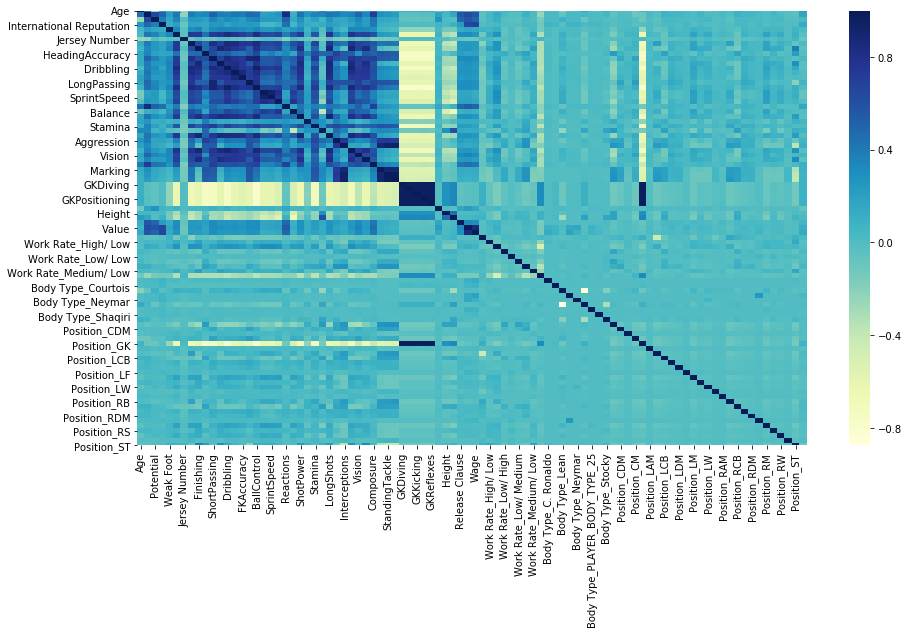

```python
X4 = FIFA.copy()


from sklearn.preprocessing import StandardScaler
X_std = StandardScaler().fit_transform(X4)
X_std1 = pd.DataFrame(X_std, columns = X4.columns)

import seaborn as sns
sns.heatmap(X_std1.corr(), cmap='YlGnBu')
plt.show()
```

We observe here the most elongated result that, the features are extremely correlated to each other, but the count is quite lesser to outoff . We can go with `PCA` to analysis the above scenario.

```python
X4 = FIFA.values

from sklearn.decomposition import PCA

pca = PCA()
pca.fit(X4)
```

```
PCA()
```

```python
np.cumsum(pca.explained_variance_ratio_)
```

```
array([0.93039201, 0.99999968, 1.        , 1.        , 1.        ,
       1.        , 1.        , 1.        , 1.        , 1.        ,
       1.        , 1.        , 1.        , 1.        , 1.        ,
       1.        , 1.        , 1.        , 1.        , 1.        ,
       1.        , 1.        , 1.        , 1.        , 1.        ,
       1.        , 1.        , 1.        , 1.        , 1.        ,
       1.        , 1.        , 1.        , 1.        , 1.        ,
       1.        , 1.        , 1.        , 1.        , 1.        ,
       1.        , 1.        , 1.        , 1.        , 1.        ,
       1.        , 1.        , 1.        , 1.        , 1.        ,
       1.        , 1.        , 1.        , 1.        , 1.        ,
       1.        , 1.        , 1.        , 1.        , 1.        ,
       1.        , 1.        , 1.        , 1.        , 1.        ,
       1.        , 1.        , 1.        , 1.        , 1.        ,
       1.        , 1.        , 1.        , 1.        , 1.        ,
       1.        , 1.        , 1.        , 1.        , 1.        ,
       1.        , 1.        , 1.        , 1.        , 1.        ,
       1.        , 1.        , 1.        , 1.        , 1.        ,
       1.        , 1.        ])
```

```python
var = np.cumsum(pca.explained_variance_ratio_)
len(var[var>0.99])
```

```
91
```

We took the entire data set, and we are observing that, one of them has been declined from the data. Hence we approach to the `PCA` to deduce our predictions for the dataset.

It is quite good that all feature are explaining 90%+ of variance, and according to our principle components, we estimate that, except a one feature, all features are doing well with 99% of variance explanation.

```python
pca  = PCA(n_components = 0.99)
X_red = pca.fit_transform(X4)
```

```python
from sklearn.cluster import KMeans
km = KMeans(n_clusters = 2)
km_pred_4 = km.fit_predict(X_red)
```

```python
fake_data['class4'] = km_pred_4
```

```python
print(fake_data['class'].value_counts())
print()
print(fake_data['class2'].value_counts())
print()
print(fake_data['class3'].value_counts())
print()
print(fake_data['class4'].value_counts())
```

```
0    15820
1     2135
Name: class, dtype: int64

0    9591
1    8364
Name: class2, dtype: int64

0    17544
1      411
Name: class3, dtype: int64

0    15820
1     2135
Name: class4, dtype: int64
```

Here we prooved one thing that, K-Means clustering is as good as that of `PCA`, we reduced the dimensioanlity of the data, for 99% variance eplaining features, we dealt with the same prediction.

For the sake of curiosity, let's see one more advanced clustering technique i.e. **DBSCAN**.

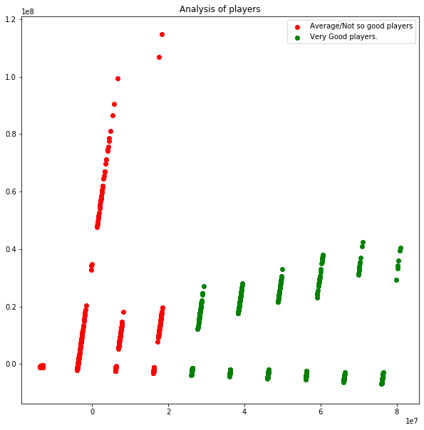

```python
import matplotlib.pyplot as plt
plt.figure(figsize = (10,10))

plt.scatter(X_red[km_pred_4==0, 0], X_red[km_pred_4==0, 1], c = 'r', label = 'Average/Not so good players')
plt.scatter(X_red[km_pred_4==1, 0], X_red[km_pred_4==1, 1], c = 'g', label = 'Very Good players.')
plt.title('Analysis of players')
plt.legend()
plt.show()
```

# DBSCAN

`Density-Based Spatial Clustering of Applications with Noise`

```python
from sklearn.cluster import DBSCAN
```

```python
dbscan_pred = DBSCAN(eps=1, min_samples=25).fit_predict(X_red)
```

```python
np.unique(dbscan_pred)
```

```
array([ -1,   0,   1,   2,   3,   4,   5,   6,   7,   8,   9,  10,  11,
        12,  13,  14,  15,  16,  17,  18,  19,  20,  21,  22,  23,  24,
        25,  26,  27,  28,  29,  30,  31,  32,  33,  34,  35,  36,  37,
        38,  39,  40,  41,  42,  43,  44,  45,  46,  47,  48,  49,  50,
        51,  52,  53,  54,  55,  56,  57,  58,  59,  60,  61,  62,  63,
        64,  65,  66,  67,  68,  69,  70,  71,  72,  73,  74,  75,  76,
        77,  78,  79,  80,  81,  82,  83,  84,  85,  86,  87,  88,  89,
        90,  91,  92,  93,  94,  95,  96,  97,  98,  99, 100, 101, 102,
       103, 104, 105, 106, 107, 108, 109, 110, 111, 112, 113, 114, 115,
       116, 117, 118, 119, 120, 121, 122, 123], dtype=int64)
```

```python
dbscan_pred = [0 if i <= dbscan_pred.mean() else 1  for i in dbscan_pred]
```

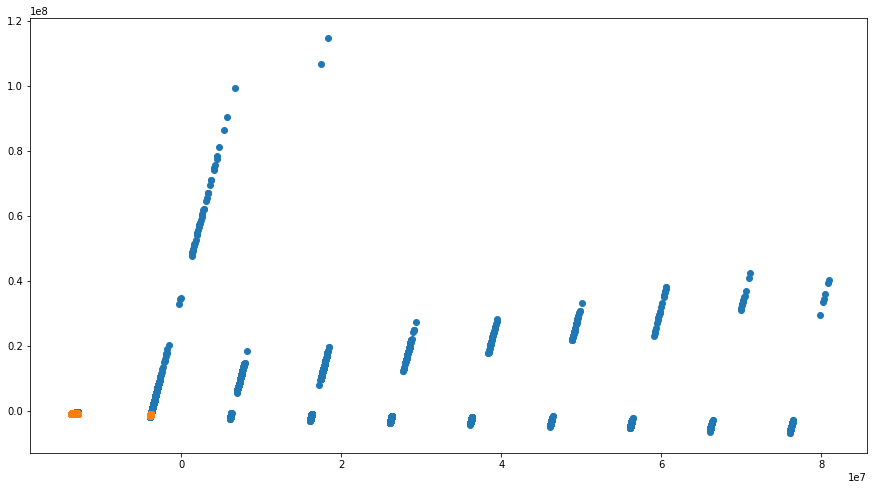

```python
for i in np.unique(np.unique(dbscan_pred)):
    plt.scatter(X_red[dbscan_pred==i,0], X_red[dbscan_pred==i,1])
plt.show()
```

```python
fake_data['class5'] = dbscan_pred
```

```python
print(fake_data['class'].value_counts())
print()
print(fake_data['class2'].value_counts())
print()
print(fake_data['class3'].value_counts())
print()
print(fake_data['class4'].value_counts())
print()
print(fake_data['class5'].value_counts())
```

```
0    15820
1     2135
Name: class, dtype: int64

0    9591
1    8364
Name: class2, dtype: int64

0    17544
1      411
Name: class3, dtype: int64

0    15820
1     2135
Name: class4, dtype: int64

0    13670
1     4285
Name: class5, dtype: int64
```

This is how we see a little imbalancing in the data. But seems better than any others. 2nd set is based on only two features that is why we see there is no imbalancing in the data. But after arranging the data `DBSCAN` is quite good. Rest all are okay with no change.

```python
ind_F = FIFA.index
ind_fifa = fifa.index

v = []
for i in ind_fifa:
    if i not in ind_F:
        v.append(i)
```

```python
fifa1 = fifa.drop(v, axis = 0)
```

```python
fifa1['Class'] = dbscan_pred
fifa1['Class'] = fifa1['Class'].replace(to_replace = [0,1], value = ['Average', 'Good'])
```

```python
fifa1.head()
```

|  | ID | Name | Age | Photo | Nationality | Flag | Overall | Potential | Club | Club Logo | ... | Marking | StandingTackle | SlidingTackle | GKDiving | GKHandling | GKKicking | GKPositioning | GKReflexes | Release Clause | Class |
| --- | --- | --- | --- | --- | --- | --- | --- | --- | --- | --- | --- | --- | --- | --- | --- | --- | --- | --- | --- | --- | --- |
| 0 | 158023 | L. Messi | 31 | https://cdn.sofifa.org/players/4/19/158023.png | Argentina | https://cdn.sofifa.org/flags/52.png | 94 | 94 | FC Barcelona | https://cdn.sofifa.org/teams/2/light/241.png | ... | 33.0 | 28.0 | 26.0 | 6.0 | 11.0 | 15.0 | 14.0 | 8.0 | €226.5M | Average |
| 1 | 20801 | Cristiano Ronaldo | 33 | https://cdn.sofifa.org/players/4/19/20801.png | Portugal | https://cdn.sofifa.org/flags/38.png | 94 | 94 | Juventus | https://cdn.sofifa.org/teams/2/light/45.png | ... | 28.0 | 31.0 | 23.0 | 7.0 | 11.0 | 15.0 | 14.0 | 11.0 | €127.1M | Average |
| 2 | 190871 | Neymar Jr | 26 | https://cdn.sofifa.org/players/4/19/190871.png | Brazil | https://cdn.sofifa.org/flags/54.png | 92 | 93 | Paris Saint-Germain | https://cdn.sofifa.org/teams/2/light/73.png | ... | 27.0 | 24.0 | 33.0 | 9.0 | 9.0 | 15.0 | 15.0 | 11.0 | €228.1M | Average |
| 3 | 193080 | De Gea | 27 | https://cdn.sofifa.org/players/4/19/193080.png | Spain | https://cdn.sofifa.org/flags/45.png | 91 | 93 | Manchester United | https://cdn.sofifa.org/teams/2/light/11.png | ... | 15.0 | 21.0 | 13.0 | 90.0 | 85.0 | 87.0 | 88.0 | 94.0 | €138.6M | Average |
| 4 | 192985 | K. De Bruyne | 27 | https://cdn.sofifa.org/players/4/19/192985.png | Belgium | https://cdn.sofifa.org/flags/7.png | 91 | 92 | Manchester City | https://cdn.sofifa.org/teams/2/light/10.png | ... | 68.0 | 58.0 | 51.0 | 15.0 | 13.0 | 5.0 | 10.0 | 13.0 | €196.4M | Average |

5 rows × 61 columns

Data Extraction:

```python
fifa1.to_csv('FIFA_PLAYERS.csv')
```

```python
fifa2 = FIFA.copy()
fifa2['Class'] = dbscan_pred
fifa2['Class'] = fifa2['Class'].replace(to_replace = [0,1], value = ['Average', 'Good'])
fifa2.to_csv('fifa_dataset_EDA.csv')
```

```python
final_data_with_eda = pd.read_csv('fifa_dataset_EDA.csv')
final_data_with_eda.head()
```

|  | Unnamed: 0 | Age | Overall | Potential | International Reputation | Weak Foot | Skill Moves | Jersey Number | Crossing | Finishing | ... | Position_RCM | Position_RDM | Position_RF | Position_RM | Position_RS | Position_RW | Position_RWB | Position_ST | Experience | Class |
| --- | --- | --- | --- | --- | --- | --- | --- | --- | --- | --- | --- | --- | --- | --- | --- | --- | --- | --- | --- | --- | --- |
| 0 | 0 | 31.0 | 94.0 | 94.0 | 5.0 | 4.0 | 4.0 | 10.0 | 84.0 | 95.0 | ... | 0 | 0 | 1 | 0 | 0 | 0 | 0 | 0 | 17.0 | Average |
| 1 | 1 | 33.0 | 94.0 | 94.0 | 5.0 | 4.0 | 5.0 | 7.0 | 84.0 | 94.0 | ... | 0 | 0 | 0 | 0 | 0 | 0 | 0 | 1 | 3.0 | Average |
| 2 | 2 | 26.0 | 92.0 | 93.0 | 5.0 | 5.0 | 5.0 | 10.0 | 79.0 | 87.0 | ... | 0 | 0 | 0 | 0 | 0 | 0 | 0 | 0 | 4.0 | Average |
| 3 | 3 | 27.0 | 91.0 | 93.0 | 4.0 | 3.0 | 1.0 | 1.0 | 17.0 | 13.0 | ... | 0 | 0 | 0 | 0 | 0 | 0 | 0 | 0 | 10.0 | Average |
| 4 | 4 | 27.0 | 91.0 | 92.0 | 4.0 | 5.0 | 4.0 | 7.0 | 93.0 | 82.0 | ... | 1 | 0 | 0 | 0 | 0 | 0 | 0 | 0 | 6.0 | Average |

5 rows × 94 columns

We have extracted 2 datasets, one is the composition of original dataset and another one is done with complete `Exploratory Data Analysis`.

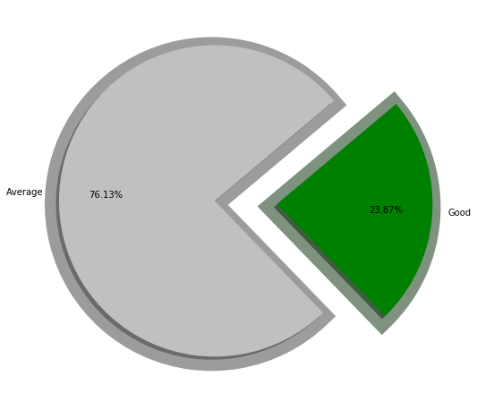

```python
plt.pie(fifa1.Class.value_counts(), autopct = '%1.2f%%',
        explode = [0.0,0.4],
        colors = ['silver', 'green'],
        labels = ['Average', 'Good'],
       shadow = True, wedgeprops = {'linewidth': 25}  , pctdistance= 0.7, startangle = 40)
plt.show()
```

As we have observed imbalancing into the set of data, we can see here not such huge imbalancing into the data with `DBSCAN`. Hence we can fix our prediction and we have exported our final dataset for further processes.

Let's do a little **Supervised Linear Classification** on the above dataset.

Here we are using the dataset `FIFA` is a previous dataset, which is the complete form of *Exploratoty Data Analysis* with *Data Preprocessing*.

```python
FIFA1 = FIFA.copy()
FIFA1['Class'] = dbscan_pred
FIFA1.head()
```

|  | Age | Overall | Potential | International Reputation | Weak Foot | Skill Moves | Jersey Number | Crossing | Finishing | HeadingAccuracy | ... | Position_RCM | Position_RDM | Position_RF | Position_RM | Position_RS | Position_RW | Position_RWB | Position_ST | Experience | Class |
| --- | --- | --- | --- | --- | --- | --- | --- | --- | --- | --- | --- | --- | --- | --- | --- | --- | --- | --- | --- | --- | --- |
| 0 | 31.0 | 94.0 | 94.0 | 5.0 | 4.0 | 4.0 | 10.0 | 84.0 | 95.0 | 70.0 | ... | 0 | 0 | 1 | 0 | 0 | 0 | 0 | 0 | 17.0 | 0 |
| 1 | 33.0 | 94.0 | 94.0 | 5.0 | 4.0 | 5.0 | 7.0 | 84.0 | 94.0 | 89.0 | ... | 0 | 0 | 0 | 0 | 0 | 0 | 0 | 1 | 3.0 | 0 |
| 2 | 26.0 | 92.0 | 93.0 | 5.0 | 5.0 | 5.0 | 10.0 | 79.0 | 87.0 | 62.0 | ... | 0 | 0 | 0 | 0 | 0 | 0 | 0 | 0 | 4.0 | 0 |
| 3 | 27.0 | 91.0 | 93.0 | 4.0 | 3.0 | 1.0 | 1.0 | 17.0 | 13.0 | 21.0 | ... | 0 | 0 | 0 | 0 | 0 | 0 | 0 | 0 | 10.0 | 0 |
| 4 | 27.0 | 91.0 | 92.0 | 4.0 | 5.0 | 4.0 | 7.0 | 93.0 | 82.0 | 55.0 | ... | 1 | 0 | 0 | 0 | 0 | 0 | 0 | 0 | 6.0 | 0 |

5 rows × 93 columns

```python
X = FIFA1.drop('Class', axis = 1)
y = FIFA1.Class
```

```python
from sklearn.model_selection import train_test_split as splt
Xtrain, Xtest, ytrain, ytest = splt(X,y, test_size = 0.6)
```

```python
from sklearn.linear_model import LogisticRegression
model = LogisticRegression().fit(Xtrain, ytrain)
```

```python
print('Train Accuracy of the model:')
print(model.score(Xtrain, ytrain))
print()
print('Test Accuracy of the model:')
print(model.score(Xtest, ytest))
```

```
Train Accuracy of the model:
0.85421888053467

Test Accuracy of the model:
0.8473962684489
```

Linear model gives good accuracy with no `overfitting` and `underfitting`.

**Let us see the classificaiton report for this:**

```python
from sklearn.metrics import classification_report
print('Classsification Report for the training data:')
print(classification_report(model.predict(Xtrain), ytrain))
print()
print('Classsification Report for the testing data:')
print(classification_report(model.predict(Xtest), ytest))
```

```
Classsification Report for the training data:
              precision    recall  f1-score   support

           0       0.90      0.91      0.90      5458
           1       0.70      0.69      0.69      1724

    accuracy                           0.85      7182
   macro avg       0.80      0.80      0.80      7182
weighted avg       0.85      0.85      0.85      7182


Classsification Report for the testing data:
              precision    recall  f1-score   support

           0       0.89      0.90      0.90      8105
           1       0.70      0.68      0.69      2668

    accuracy                           0.85     10773
   macro avg       0.80      0.79      0.79     10773
weighted avg       0.85      0.85      0.85     10773
```

The same scenario we face here as well.

```python
from sklearn.tree import DecisionTreeClassifier
dt = DecisionTreeClassifier()
dt.fit(Xtrain, ytrain)
```

```
DecisionTreeClassifier()
```

```python
print('Accuracy with Train Dataset.')
print(dt.score(Xtrain, ytrain))
print()
print('Accuracy with Test Dataset.')
print(dt.score(Xtest, ytest).round(2))
```

```
Accuracy with Train Dataset.
1.0

Accuracy with Test Dataset.
0.96
```

```python
from sklearn.ensemble import RandomForestClassifier
rf = RandomForestClassifier()
rf.fit(Xtrain, ytrain)
```

```
RandomForestClassifier()
```

```python
print('Accuracy with Train Dataset.')
print(rf.score(Xtrain, ytrain))
print()
print('Accuracy with Test Dataset.')
print(rf.score(Xtest, ytest).round(2))
```

```
Accuracy with Train Dataset.
1.0

Accuracy with Test Dataset.
0.88
```

Descision Tree Classifier and Random Forest Model gave the issue of `overfitting` but still their accuracy is quit good.

We were fit in `Logistic Regression` since it is more precise and prior dataset. It is giving low accuracy but no issue of `Overfitting` and `Underfitting`.

Yet we are done with our work on FIFA players prediction Project.